# na exploration

Still haven’t removed columns / modified / created new dataset Code should be robust enough to work on the merged dataset and modify that directly Some considerations as comments below graphs

```r
library(naniar)
library(hash)
library(assert)
library(ggplot2)
library(UpSetR)
library(visdat)
source("include.R")
```

```
❤ Loaded agrimonia dataset. Available as df_agri.
❤ Converted df_agri$Time to Date variable type, year-month-day.
❤ Created DATE_FORMAT variable for date comparisons.
❤ Loaded stations split dataset. Available as df_stat.
```

Visualize dataset and summary

```r
# dati = read.csv("Agrimonia_Dataset_v_3_0_0.csv")
dati = df_agri
head(dati)
```

|  | IDStations | Latitude | Longitude | Time | Altitude | AQ_pm10 | AQ_pm25 | AQ_co | AQ_nh3 | AQ_nox | AQ_no2 | AQ_so2 | WE_temp_2m | WE_wind_speed_10m_mean | WE_wind_speed_10m_max | WE_mode_wind_direction_10m | WE_tot_precipitation | WE_precipitation_t | WE_surface_pressure | WE_solar_radiation | WE_rh_min | WE_rh_mean | WE_rh_max | WE_wind_speed_100m_mean | WE_wind_speed_100m_max | WE_mode_wind_direction_100m | WE_blh_layer_max | WE_blh_layer_min | EM_nh3_livestock_mm | … |
| --- | --- | --- | --- | --- | --- | --- | --- | --- | --- | --- | --- | --- | --- | --- | --- | --- | --- | --- | --- | --- | --- | --- | --- | --- | --- | --- | --- | --- | --- | --- |
| 1 | 1264 | 46.16785 | 9.87921 | 2016-01-01 | 290 | 62 | 53 | NaN | NaN | 82.63 | 37.72 | NaN | -2.212 | 0.5970 | 0.9883 | S | 2.117e-05 | 0 | 83720 | 5664000 | 58.11 | 74.66 | 96.33 | 1.0730 | 1.977 | S | 340.6 | 10.63 | 0.2015 | … |
| 2 | 1264 | 46.16785 | 9.87921 | 2016-01-02 | 290 | 73 | 63 | NaN | NaN | 101.70 | 38.84 | NaN | -3.063 | 0.4402 | 0.7365 | SE | 8.282e-03 | 5 | 82990 | 1335000 | 75.57 | 89.69 | 96.61 | 1.0530 | 2.321 | S | 238.7 | 21.55 | 0.2020 | … |
| 3 | 1264 | 46.16785 | 9.87921 | 2016-01-03 | 290 | 44 | 39 | NaN | NaN | 66.26 | 32.34 | NaN | -2.768 | 0.6954 | 1.0100 | S | 2.486e-03 | 5 | 82320 | 3728000 | 62.20 | 82.27 | 93.49 | 1.9810 | 2.942 | S | 407.0 | 22.80 | 0.2024 | … |
| 4 | 1264 | 46.16785 | 9.87921 | 2016-01-04 | 290 | 31 | 29 | NaN | NaN | 63.31 | 31.67 | NaN | -4.352 | 0.5812 | 0.9421 | W | 4.133e-03 | 5 | 81410 | 1846000 | 64.27 | 83.39 | 97.39 | 1.2080 | 2.284 | N | 536.7 | 12.21 | 0.2027 | … |
| 5 | 1264 | 46.16785 | 9.87921 | 2016-01-05 | 290 | 27 | 26 | NaN | NaN | 75.53 | 33.33 | NaN | -6.184 | 0.5906 | 0.9847 | SE | 8.466e-04 | 5 | 81530 | 1733000 | 58.48 | 73.85 | 95.66 | 0.8226 | 1.672 | SE | 472.4 | 10.15 | 0.2031 | … |
| 6 | 1264 | 46.16785 | 9.87921 | 2016-01-06 | 290 | 27 | 25 | NaN | NaN | 61.36 | 34.40 | NaN | -6.427 | 0.8223 | 1.0820 | S | 1.444e-04 | 0 | 81660 | 2688000 | 48.94 | 64.94 | 85.71 | 1.6300 | 2.379 | SE | 592.1 | 13.31 | 0.2034 | … |

```r
dim(dati)
```

```
[1] 309072     43
```

```r
summary(dati)
```

```
  IDStations           Latitude       Longitude           Time               Altitude
 Length:309072      Min.   :44.57   Min.   : 8.284   Min.   :2016-01-01   Min.   :   4
 Class :character   1st Qu.:45.10   1st Qu.: 9.045   1st Qu.:2017-07-01   1st Qu.:  61
 Mode  :character   Median :45.43   Median : 9.556   Median :2018-12-31   Median : 118
                    Mean   :45.39   Mean   : 9.721   Mean   :2018-12-31   Mean   : 173
                    3rd Qu.:45.65   3rd Qu.:10.337   3rd Qu.:2020-07-01   3rd Qu.: 210
                    Max.   :46.62   Max.   :11.650   Max.   :2021-12-31   Max.   :1601

    AQ_pm10          AQ_pm25           AQ_co            AQ_nh3           AQ_nox
 Min.   :  0.00   Min.   :  0.00   Min.   :0.00     Min.   :  0.00   Min.   :  0.00
 1st Qu.: 15.00   1st Qu.:  9.08   1st Qu.:0.29     1st Qu.:  4.30   1st Qu.: 18.22
 Median : 23.00   Median : 15.00   Median :0.44     Median :  8.80   Median : 32.81
 Mean   : 28.07   Mean   : 20.25   Mean   :0.52     Mean   : 15.79   Mean   : 50.36
 3rd Qu.: 36.00   3rd Qu.: 26.00   3rd Qu.:0.68     3rd Qu.: 18.00   3rd Qu.: 64.02
 Max.   :264.00   Max.   :182.00   Max.   :2.98     Max.   :430.60   Max.   :776.20
 NA's   :89634    NA's   :208386   NA's   :197180   NA's   :292617   NA's   :107843
     AQ_no2           AQ_so2         WE_temp_2m     WE_wind_speed_10m_mean WE_wind_speed_10m_max
 Min.   :  0.00   Min.   : 0.00    Min.   :-24.14   Min.   :0.2309         Min.   : 0.3727
 1st Qu.: 14.08   1st Qu.: 1.37    1st Qu.:  6.06   1st Qu.:1.0220         1st Qu.: 1.7000
 Median : 23.25   Median : 2.39    Median : 12.69   Median :1.3130         Median : 2.1470
 Mean   : 26.85   Mean   : 3.06    Mean   : 12.83   Mean   :1.4748         Mean   : 2.4314
 3rd Qu.: 36.17   3rd Qu.: 3.71    3rd Qu.: 19.69   3rd Qu.:1.7390         3rd Qu.: 2.8640
 Max.   :147.20   Max.   :76.04    Max.   : 33.08   Max.   :7.0360         Max.   :10.4500
 NA's   :49132    NA's   :227026
 WE_mode_wind_direction_10m WE_tot_precipitation WE_precipitation_t WE_surface_pressure
 Length:309072              Min.   :0.000e+00    Min.   :0.0000     Min.   : 74670
 Class :character           1st Qu.:4.810e-06    1st Qu.:0.0000     1st Qu.: 97270
 Mode  :character           Median :2.580e-04    Median :0.0000     Median : 99470
                            Mean   :3.288e-03    Mean   :0.3764     Mean   : 98040
                            3rd Qu.:2.715e-03    3rd Qu.:1.0000     3rd Qu.:100600
                            Max.   :1.717e-01    Max.   :8.0000     Max.   :104300

 WE_solar_radiation   WE_rh_min        WE_rh_mean      WE_rh_max      WE_wind_speed_100m_mean
 Min.   :  149100   Min.   : 8.168   Min.   :19.49   Min.   : 26.19   Min.   : 0.4357
 1st Qu.: 5629750   1st Qu.:44.430   1st Qu.:65.78   1st Qu.: 86.96   1st Qu.: 1.6540
 Median :11240000   Median :55.020   Median :74.96   Median : 92.93   Median : 2.2450
 Mean   :11469306   Mean   :56.160   Mean   :74.22   Mean   : 90.62   Mean   : 2.5836
 3rd Qu.:17200000   3rd Qu.:67.100   3rd Qu.:83.90   3rd Qu.: 96.67   3rd Qu.: 3.1380
 Max.   :26660000   Max.   :98.970   Max.   :99.53   Max.   :100.00   Max.   :13.0500

```

[output cut: 17 more lines]

```
 Min.   :  0.31   Min.   : 0.01   Min.   :   0.000   Min.   :  0.000   Length:309072
 1st Qu.:  3.30   1st Qu.: 0.45   1st Qu.:   0.266   1st Qu.:  3.168   Class :character
 Median :  7.00   Median : 1.16   Median :   1.494   Median : 12.060   Mode  :character
 Mean   : 12.78   Mean   : 2.95   Mean   : 106.617   Mean   : 37.853
 3rd Qu.: 15.32   3rd Qu.: 3.12   3rd Qu.:  78.730   3rd Qu.: 46.630
 Max.   :124.00   Max.   :45.06   Max.   :2602.000   Max.   :448.800
 NA's   :51465    NA's   :51465   NA's   :6576       NA's   :6576
 LI_bovine_v2           LA_hvi          LA_lvi        LA_land_use     LA_soil_use
 Length:309072      Min.   :0.837   Min.   :0.7174   Min.   :111.0   Min.   : 2.00
 Class :character   1st Qu.:1.865   1st Qu.:1.7590   1st Qu.:112.0   1st Qu.:10.00
 Mode  :character   Median :2.141   Median :2.2355   Median :112.0   Median :17.00
                    Mean   :2.331   Mean   :2.1772   Mean   :134.7   Mean   :13.79
                    3rd Qu.:2.470   3rd Qu.:2.6170   3rd Qu.:121.0   3rd Qu.:17.00
                    Max.   :5.037   Max.   :3.6620   Max.   :333.0   Max.   :21.00
                                                                     NA's   :173199
```

Count of na for each column

```r
sum(is.na(dati))
```

```
[1] 1718424
```

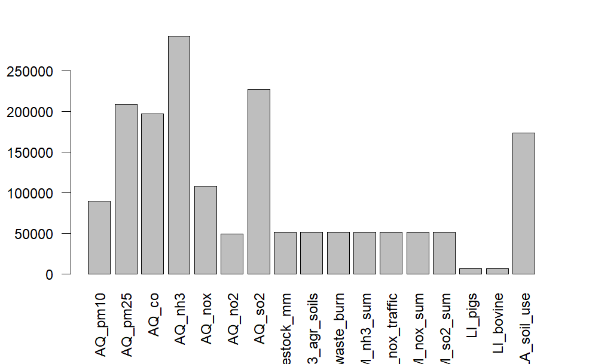

```r
nas = sapply(dati,function(x) sum(is.na(x)))
barplot(nas[nas>0],las=2)
```

plot na for columns to see if there is any pattern

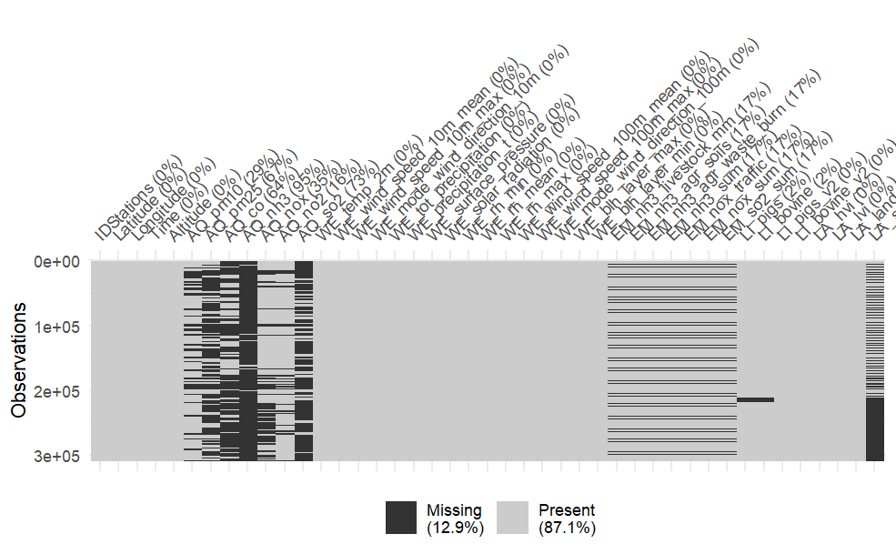

```r
# x11()  #too big of a graph for the notebook
dev.new()
vis_miss(dati,warn_large_data = FALSE)
```

#can see different patterns -> #blocks for some of the AQ variables -> would remove #regular “stripes” on the EM variables -> see how useful/sparse the problem is #stripes and then a block at the bottom for the soil use var -> would remove

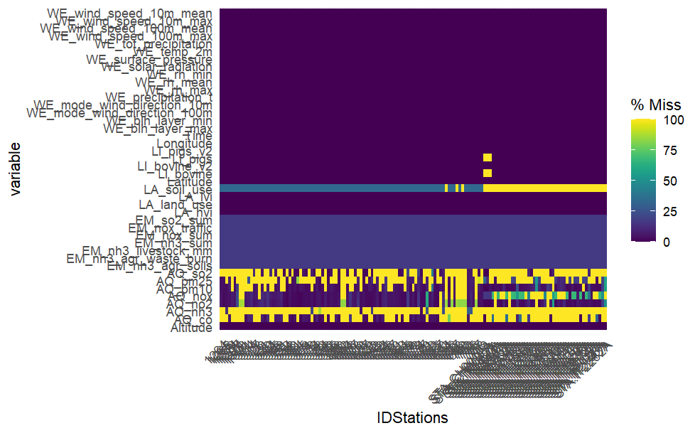

```r
gg_miss_fct(x = dati,fct = IDStations)
```

Messy plot but plotted faster than the one before Stations are on the horizontal axis

Try with dataset divided by station

```r
dati = df_agri # loade on top by include.R
df_stat=hash()
stations = unique(dati$IDStations)
print(stations)
```

```
  [1] "1264"        "1265"        "1266"        "1269"        "1274"        "1297"
  [7] "1374"        "1800"        "1801"        "501"         "504"         "514"
 [13] "517"         "528"         "529"         "531"         "539"         "542"
 [19] "544"         "545"         "546"         "548"         "551"         "552"
 [25] "554"         "558"         "560"         "561"         "564"         "565"
 [31] "569"         "571"         "572"         "573"         "574"         "576"
 [37] "583"         "584"         "588"         "592"         "595"         "596"
 [43] "598"         "600"         "602"         "603"         "604"         "606"
 [49] "607"         "608"         "609"         "626"         "627"         "629"
 [55] "633"         "642"         "643"         "649"         "652"         "654"
 [61] "655"         "656"         "657"         "659"         "661"         "663"
 [67] "664"         "665"         "669"         "670"         "672"         "673"
 [73] "674"         "677"         "679"         "681"         "682"         "683"
 [79] "685"         "687"         "690"         "693"         "694"         "695"
 [85] "696"         "697"         "698"         "699"         "700"         "702"
 [91] "703"         "705"         "706"         "707"         "708"         "709"
 [97] "STA-CH0011A" "STA-CH0033A" "STA-CH0043A" "STA.IT0187A" "STA.IT0499A" "STA.IT0544A"
[103] "STA.IT0591A" "STA.IT0643A" "STA.IT0721A" "STA.IT0753A" "STA.IT0804A" "STA.IT0940A"
[109] "STA.IT1026A" "STA.IT1105A" "STA.IT1152A" "STA.IT1191A" "STA.IT1336A" "STA.IT1509A"
[115] "STA.IT1510A" "STA.IT1518A" "STA.IT1532A" "STA.IT1533A" "STA.IT1535A" "STA.IT1582A"
[121] "STA.IT1676A" "STA.IT1751A" "STA.IT1771A" "STA.IT1830A" "STA.IT1878A" "STA.IT1904A"
[127] "STA.IT1910A" "STA.IT1914A" "STA.IT1917A" "STA.IT1918A" "STA.IT1921A" "STA.IT1923A"
[133] "STA.IT1924A" "STA.IT1975A" "STA.IT2072A" "STA.IT2074A" "STA.IT2102A" "STA.IT2121A"
[139] "STA.IT2156A" "STA.IT2243A" "STA.IT2282A"
```

```r
for (st in stations){
  df_stat[[st]] = dati[which(dati$IDStations == st),]
  assert(dim(df_stat[[st]])[1] == 2192) # make sure each df_stat has all his 2192 obs
}
```

Visualize if all ok

```r
#example
dati_1264=df_stat[["1264"]]
dim(dati_1264)
```

```
[1] 2192   43
```

```r
head(dati_1264)
```

|  | IDStations | Latitude | Longitude | Time | Altitude | AQ_pm10 | AQ_pm25 | AQ_co | AQ_nh3 | AQ_nox | AQ_no2 | AQ_so2 | WE_temp_2m | WE_wind_speed_10m_mean | WE_wind_speed_10m_max | WE_mode_wind_direction_10m | WE_tot_precipitation | WE_precipitation_t | WE_surface_pressure | WE_solar_radiation | WE_rh_min | WE_rh_mean | WE_rh_max | WE_wind_speed_100m_mean | WE_wind_speed_100m_max | WE_mode_wind_direction_100m | WE_blh_layer_max | WE_blh_layer_min | EM_nh3_livestock_mm | … |
| --- | --- | --- | --- | --- | --- | --- | --- | --- | --- | --- | --- | --- | --- | --- | --- | --- | --- | --- | --- | --- | --- | --- | --- | --- | --- | --- | --- | --- | --- | --- |
| 1 | 1264 | 46.16785 | 9.87921 | 2016-01-01 | 290 | 62 | 53 | NaN | NaN | 82.63 | 37.72 | NaN | -2.212 | 0.5970 | 0.9883 | S | 2.117e-05 | 0 | 83720 | 5664000 | 58.11 | 74.66 | 96.33 | 1.0730 | 1.977 | S | 340.6 | 10.63 | 0.2015 | … |
| 2 | 1264 | 46.16785 | 9.87921 | 2016-01-02 | 290 | 73 | 63 | NaN | NaN | 101.70 | 38.84 | NaN | -3.063 | 0.4402 | 0.7365 | SE | 8.282e-03 | 5 | 82990 | 1335000 | 75.57 | 89.69 | 96.61 | 1.0530 | 2.321 | S | 238.7 | 21.55 | 0.2020 | … |
| 3 | 1264 | 46.16785 | 9.87921 | 2016-01-03 | 290 | 44 | 39 | NaN | NaN | 66.26 | 32.34 | NaN | -2.768 | 0.6954 | 1.0100 | S | 2.486e-03 | 5 | 82320 | 3728000 | 62.20 | 82.27 | 93.49 | 1.9810 | 2.942 | S | 407.0 | 22.80 | 0.2024 | … |
| 4 | 1264 | 46.16785 | 9.87921 | 2016-01-04 | 290 | 31 | 29 | NaN | NaN | 63.31 | 31.67 | NaN | -4.352 | 0.5812 | 0.9421 | W | 4.133e-03 | 5 | 81410 | 1846000 | 64.27 | 83.39 | 97.39 | 1.2080 | 2.284 | N | 536.7 | 12.21 | 0.2027 | … |
| 5 | 1264 | 46.16785 | 9.87921 | 2016-01-05 | 290 | 27 | 26 | NaN | NaN | 75.53 | 33.33 | NaN | -6.184 | 0.5906 | 0.9847 | SE | 8.466e-04 | 5 | 81530 | 1733000 | 58.48 | 73.85 | 95.66 | 0.8226 | 1.672 | SE | 472.4 | 10.15 | 0.2031 | … |
| 6 | 1264 | 46.16785 | 9.87921 | 2016-01-06 | 290 | 27 | 25 | NaN | NaN | 61.36 | 34.40 | NaN | -6.427 | 0.8223 | 1.0820 | S | 1.444e-04 | 0 | 81660 | 2688000 | 48.94 | 64.94 | 85.71 | 1.6300 | 2.379 | SE | 592.1 | 13.31 | 0.2034 | … |

Graph as before for each and all of the stations to see if any has interestingly distributed missing values

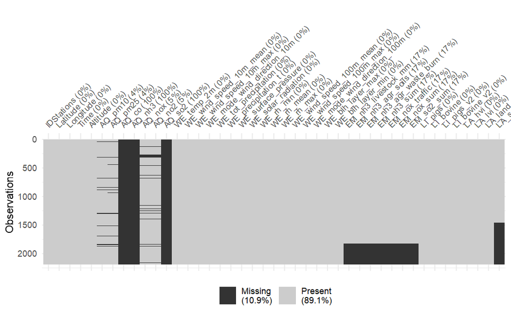

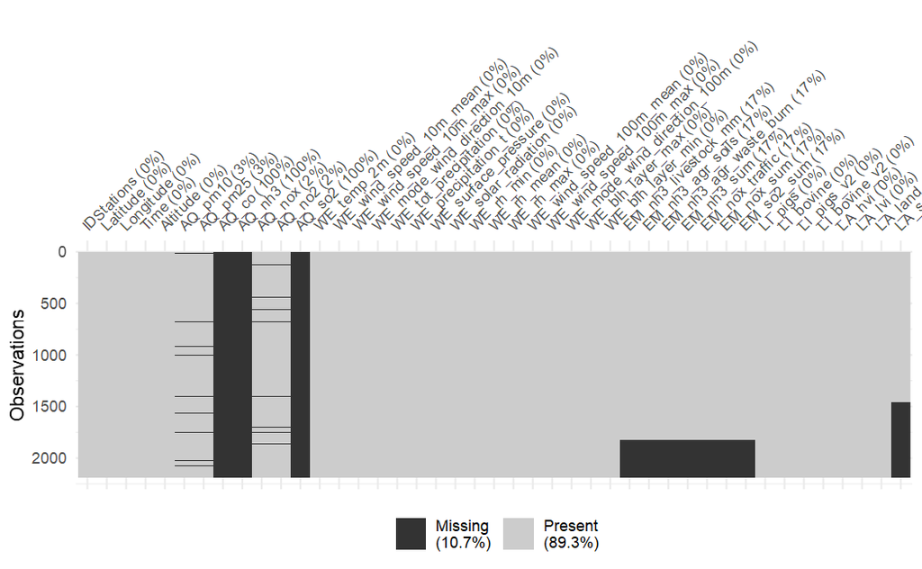

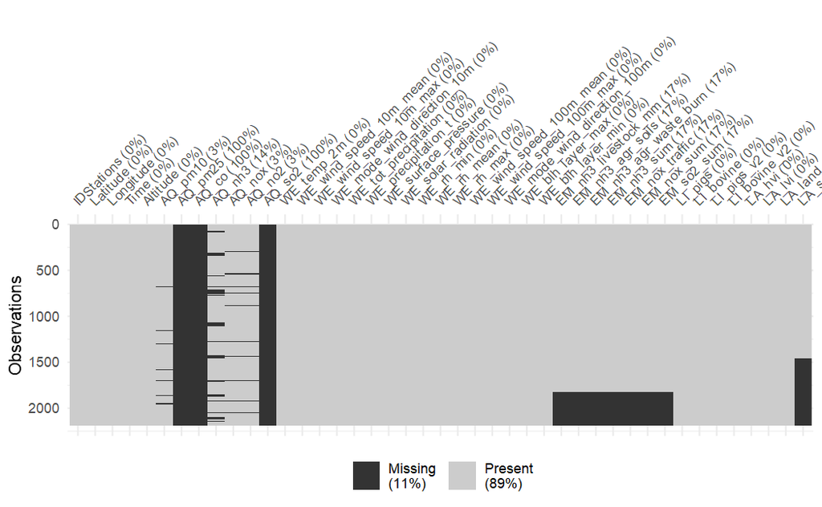

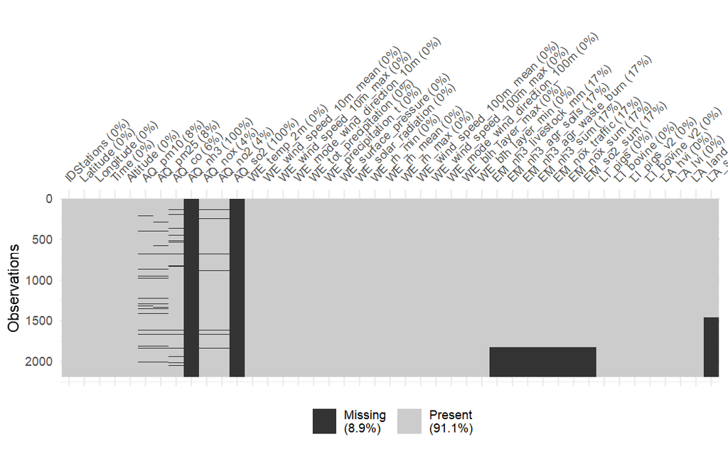

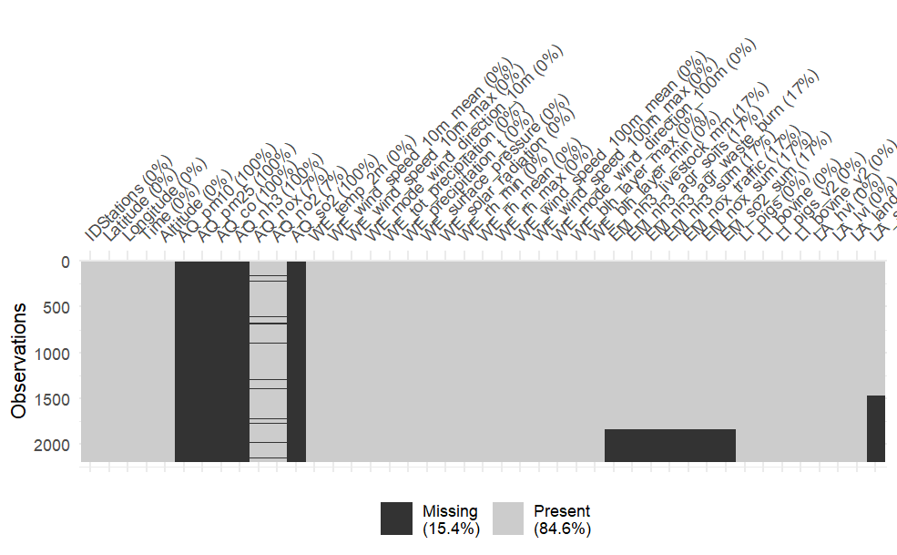

```r
NSTAT = 5 # 141 if want to see them all

for (st in stations[1:NSTAT]){
  # df_stat[[st]] = dati[which(dati$IDStations == st),]
  # assert(dim(df_stat[[st]])[1] == 2192) # make sure each df_stat has all his 2192 obs

  # sometimes it didnt work for me so i am just proving different options here
  # plot(vis_miss(df_stat[[st]],warn_large_data = FALSE)) #a plot for each station
  plot(vis_miss(as.data.frame(df_stat[[st]]),warn_large_data = FALSE)) #a plot for each station
}
```

#can see graphically for every variable #notice how for some stations EM have na only on last year or so #We could substitute with mean or median for EM variables using mean of first years of same station but risk losing temporal changing -> maybe not good idea (?)

With another plot

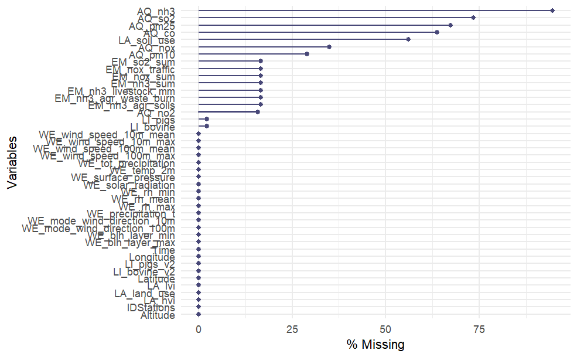

```r
gg_miss_var(dati,show_pct = TRUE)
```

Plot to see combinations of variables with the most na

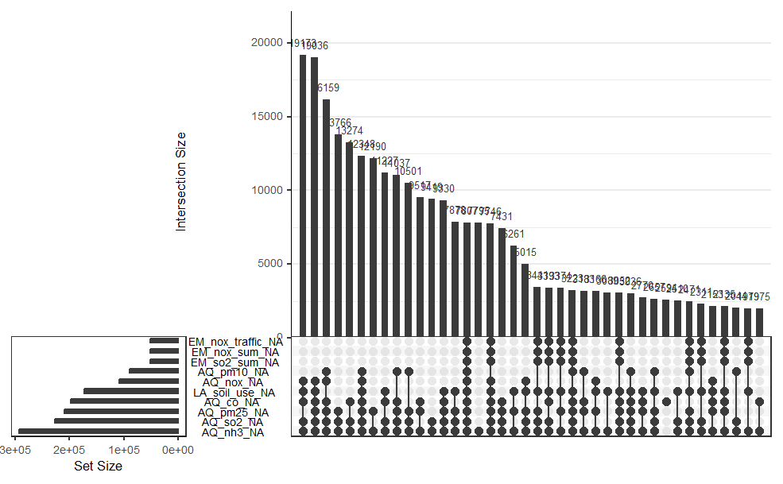

```r
gg_miss_upset(dati,nsets = 10)
```

To do all graphs above with a single function on the dataset

```r
inspect_df_NA <- function(df){
  plot_list <- list()
  plot_list$miss_table <- vis_miss(df,warn_large_data = FALSE)
  plot_list$interceptions <- gg_miss_upset(df,nsets = 10)
  plot_list$heatmap <- gg_miss_fct(x = df,fct = IDStations)
  plot_list$percentage <- gg_miss_var(df, show_pct = TRUE)

  return(plot_list)
}
```

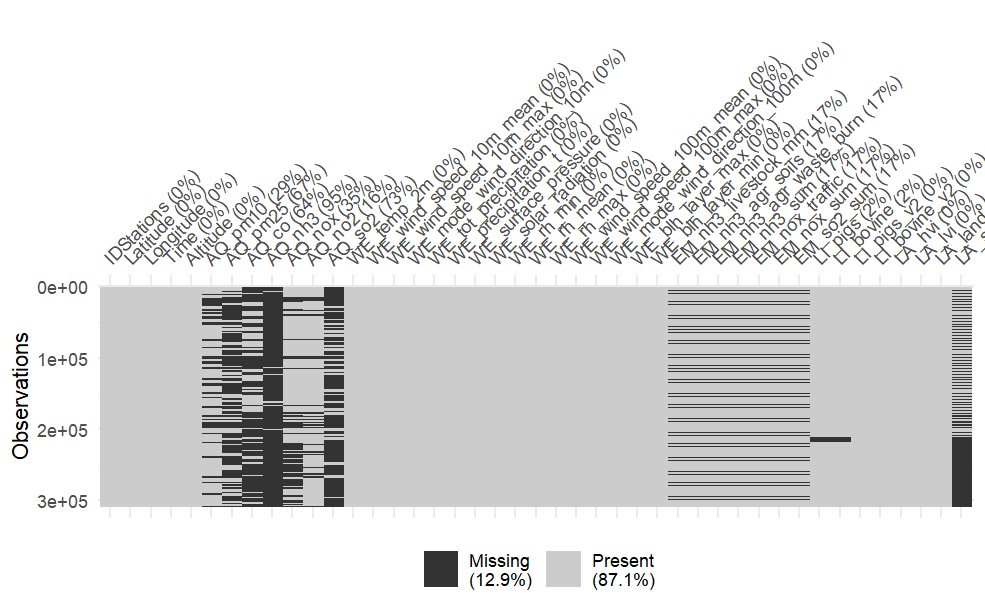

```r
plots <- inspect_df_NA(dati)

plots$miss_table
```

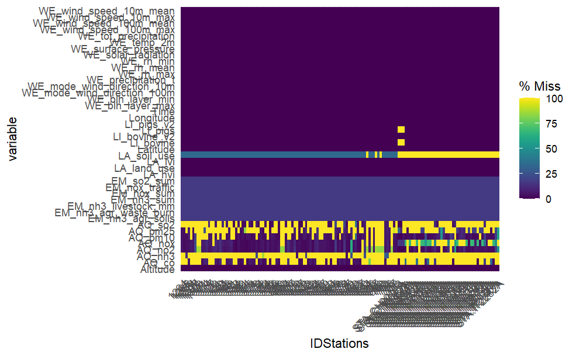

```r
plots$heatmap
```

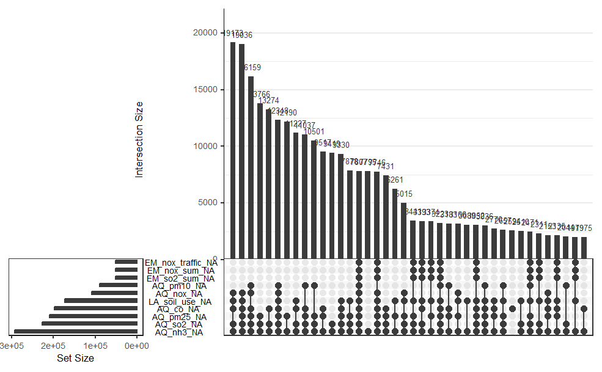

```r
plots$interceptions
```

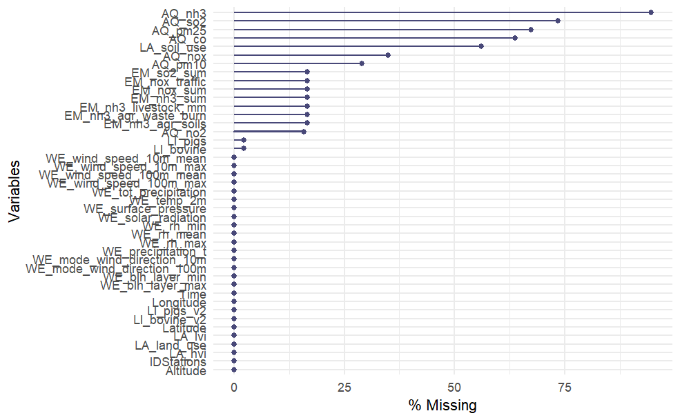

```r
plots$percentage
```